# Managing Python Virtual Environments with UV

github.com/marcdotson/pydata-uv

Kaden Buffaloe and Marc Dotson

[figure not shown]

- Club and professional forum to learn/retool
- Global network of chapters
- Workshops vary from beginning to advanced
- Polyglot (Python, Julia, R, etc.)
- We follow the [PyData Code of Conduct](https://pydata.org/code-of-conduct/)
- Join at [meetup.com/pydata-northern-utah](https://www.meetup.com/pydata-northern-utah/)

# Python Environments

I recommend using [uv](https://docs.astral.sh/uv/), a single unified tool for installing and managing both Python versions and project environments

## Create an Environment: Traditional vs `uv`

### Traditional Approach

1. Manage Python version using `pyenv`

```bash
pyenv local 3.11.7
```

2. Create a Virtual Environment

```bash
python -m venv venv
```

3. Activate the Environment

```bash
.\venv\Scripts\activate
```

4. Install Packages Manually

```bash
pip install requests pandas
```

5. Freeze Dependencies

```bash
pip freeze > requirements.txt
```

### Using `uv`

1. Initialize a project

```bash
uv init
```

2. Install & pin Python version (optional)

```bash
uv python install 3.11
uv python pin 3.11
```

3. Add packages to the project

```bash
uv add requests pandas
```

- `uv` tracks dependencies in a `uv.lock` file and automatically creates the `.venv environment`—no requirements.txt needed.

# Walkthrough- Let’s See It In Action

## Installation

Get started by [installing uv](https://docs.astral.sh/uv/getting-started/installation/) via the command line

**The Command Line**

If using the command line (i.e., terminal or shell) is new to you, be patient, take your time, and follow instructions from a trusted source closely. A few things that might help:

- The command line is the programming interface into your OS itself. You don’t have to know everything about it to follow instructions.
- Instructions can be different based on the *type* of command line. If you’re on a Mac that’s running macOS Catalina 10.15.7 or later, the terminal is Zsh. If you’re using Linux, the shell is Bash (and you probably already know that). And if you’re using Windows you’re working with PowerShell.

## Download the Latest Version of `uv`

#### macOS and Linux

- Press `Cmd + Space`, type **Terminal**, and enter the following:

```bash
# Install the latest version of uv
curl -LsSf https://astral.sh/uv/install.sh | sh
```

#### Windows

- Open the Start Menu, type **PowerShell**, press Enter, and copy the following:

```powershell
powershell -ExecutionPolicy ByPass -c "irm https://astral.sh/uv/install.ps1 | iex"
```

**Verify Installation**

- You can simply run `uv -- version` in the command line to verify it has been installed.

## Managing Python Versions

Once you have uv installed, it’s easy to install and manage Python versions, no need for `pyenv`. From the command line you can run:

```bash
#Install the latest stable release of Python or a specific version.
uv python install
uv python install 3.13

#View available Python versions to install.
uv python list

#Find an installed Python version.
uv python find

#Pin the current project to use a specific Python version.
uv python pin
uv python pin 3.13.7

#Uninstall a Python version.
uv python uninstall
```

## Navigate to a Projecet Directory

Using the command line or using a code editor or IDE like [Positron](https://github.com/marcdotson/data-stack?tab=readme-ov-file#sec-positron), locate or create the directory you would like to use. This working directory **should not** be in a location on your local machine **that is being synced to the cloud** via OneDrive, iCloud, etc.

### macOS and Linux

```bash
# Replace with the actual path to your folder
cd ~/Documents/my-python-project-folder
```

### Windows

```powershell
# Replace with the actual path to your folder
cd C:\Users\YourUser\Documents\my-python-project-folder
```

**Pro Tip**

- Dragging a folder from your file explorer and dropping it into the terminal window will paste its full path automatically!

## Create a Project Environment

- **Run `uv init`** to initialize a project environment.

  ```bash
  uv init
  ```

  - This creates a `pyproject.toml` file with metadata about the project and a hidden `.python-version` file that specifies the default version of Python for the project.
  - It also creates `main.py` and `README.md` files that you can use or delete.

**Before** Running `uv init`

```
my-python-project
├── data
├── figures
└── presentations
```

**After** Running `uv init`

```
my-python-project
├── data
├── figures
├── presentations
├── .gitignore
├── .python-version
├── main.py
├── pyproject.toml
└── README.md
```

## Add Packages

With the project environment initialized, you can now install libraries. For example, to install the `Pandas` library, run:

```bash
uv add pandas
```

- This installs `Pandas`, and any dependencies, and creates both a `uv.lock` file that keeps track of the versions of the libraries you’ve installed and a hidden `.venv` reproducible environment folder that serves as the project library.
- Whenever you install new libraries, the `uv.lock` file is automatically updated.

**Before** Running `uv add <package>`

```
my-python-project
├── data
├── figures
├── presentations
├── .gitignore
├── .python-version
├── main.py
├── pyproject.toml
└── README.md
```

**After** Running `uv add <package>`

```
my-python-project
├── .venv
├── data
├── figures
├── presentations
├── .gitignore
├── .python-version
├── main.py
├── pyproject.toml
├── README.md
└── uv.lock
```

## Run Code In Your Environment

With packages now installed `uv` can be used to run code in your environment. No need to activate/deactivate your venv — `uv run` does it. If the `.venv` somehow gets deleted `uv` will check prior to running and re-initailize it.

```bash
uv run main.py
```

```python
import pandas as pd
import matplotlib.pyplot as plt

# --- USU Color Scheme ---
usu_colors = ['#003366','#9D9D9D','#6699CC', '#0055A4' ]

# Load customer data and establish region counts
customer_data = pd.read_csv('../data/customer_data.csv')
region_counts = customer_data['region'].value_counts()

#Plot regional customer distributions
fig, ax = plt.subplots(figsize=(8, 8))
region_counts.plot.pie(
    ax=ax,
    autopct='%1.1f%%',
    startangle=90,
    colors=usu_colors[:len(region_counts)])

ax.set_title('Customer Region Distribution', fontsize=16, color='#003366', fontweight='bold')

ax.set_ylabel('')
plt.show()
```

## Run Code In Your Environment

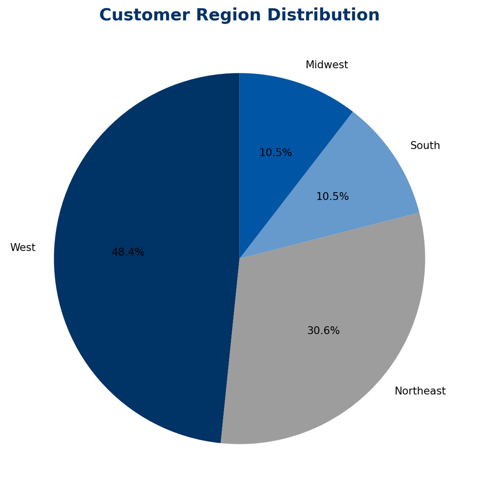

## Other Useful Features

`uv` offers several powerful commands to streamline project management and collaboration.

- **Auto-Install on Run** If you’re starting with an existing project, `uv run` automatically installs any missing libraries from the `uv.lock` file before executing your code.

```bash
# No need to run 'uv sync' first!
uv run python your_script.py
```

- **Export for Compatibility** To share your project with someone using a different tool (like `pip`), you can export your environment’s dependencies into standard formats.
- For a `requirements.txt` file:

```bash
uv export --format requirements.txt
```

- For a `pylock.toml` file:

```bash
uv export -o pylock.toml
```

See more in depth use set up at [the data stack training](https://github.com/marcdotson/data-stack)

# Thank You!

[figure not shown]